# Chapter 1. Data

### 다양한 종류의 자료들을 보고 통계적 지식을 활용해 자료를 요약하고, 보고하고, 요약하는 것이 우리의 목표

## 1.2 Some R essentials

```r
library(UsingR)
```

```r
## 1.2.2 Using R as a calculator

2+2
2^2
```

4

4

```r
## Functions

sqrt(2)
sin(pi)
exp(1)
log(10)
```

1.4142135623731

1.22460635382238e-16

2.71828182845905

2.30258509299405

```r
log(10, 2)
log(10, base = 2)
```

3.32192809488736

3.32192809488736

```r
?log
```

```r
## warnings and errors: wrong function names, wrong syntax, impossible calculation
```

```r
## Assignment
## use either '=' or '<-'

x  12
y = 3
x+y
```

```
Error in parse(text = x, srcfile = src): <text>:4:4: 예상하지 못한 수치형 상수(numeric constant)입니다.
3:
4: x  12
      ^
Traceback:
```

```r
pi
e
```

3.14159265358979

```
Error in eval(expr, envir, enclos): 객체 'e'를 찾을 수 없습니다
Traceback:
```

```r
e = exp(1)
e^2
```

7.38905609893065

```r
## Acceptable variable names
## Variable names are CaSe SEnsiTIve.
## 1No variable can start with a numeric value.
## Variable names can contain dots(.), or underbars(_).
## Variable names cannot contain mathematical operators (+, -, *, /)

variable.1 <- 11

variable.1

variable_2 <- 22

variable_2
```

11

22

```r
## 1.2.4 Using c() to enter data

## data vector: can be made with the c() function
whales <- c(74, 122, 235, 111, 292, 111, 211, 133, 156, 79)
whales
```

1. 74

2. 122

3. 235

4. 111

5. 292

6. 111

7. 211

8. 133

9. 156

10. 79

```r
## c() function can combine data vectors
x <- c(4, 7, 21)
y <- c(5, 88, 123)
xandy<- c(x,y)
```

```r
xandy
```

1. 4

2. 7

3. 21

4. 5

5. 88

6. 123

```r
whales2 <- whales
str(whales2)
```

```
 num [1:10] 74 122 235 111 292 111 211 133 156 79
```

```r
## Data vectors have a type

## numeric
str(whales)

## character
simpsons <- c("Homer", "Marge", "Bart", "Lisa", "Maggie")
str(simpsons)

## named numeric
whales.named <- whales
names(whales.named) <- c("a", "b", "c", "d", "e", "f", "g", "h", "i", "j")
str(whales.named)

## named character
simpsons.named <- simpsons
names(simpsons.named) <- c("dad", "mom", "son", "daughter 1", "daughter 2")
str(simpsons.named)
```

```
 num [1:10] 74 122 235 111 292 111 211 133 156 79
 chr [1:5] "Homer" "Marge" "Bart" "Lisa" "Maggie"
 Named num [1:10] 74 122 235 111 292 111 211 133 156 79
 - attr(*, "names")= chr [1:10] "a" "b" "c" "d" ...
 Named chr [1:5] "Homer" "Marge" "Bart" "Lisa" "Maggie"
 - attr(*, "names")= chr [1:5] "dad" "mom" "son" "daughter 1" ...
```

```r
whales[5]
```

292

```r
simpsons.named["dad"]
```

**dad:** 'Homer'

```r
## 1.2.5 Using functions on a data vector

sum(whales)
length(whales)
sum(whales)/length(whales)     # mean(whales)
mean(whales)

sort(whales)
sort(whales, decreasing=F)
min(whales)
max(whales)
range(whales)
whales
diff(whales)
diff(whales, lag=2)
cumsum(whales)
```

1524

10

152.4

152.4

1. 74

2. 79

3. 111

4. 111

5. 122

6. 133

7. 156

8. 211

9. 235

10. 292

1. 74

2. 79

3. 111

4. 111

5. 122

6. 133

7. 156

8. 211

9. 235

10. 292

74

292

1. 74

2. 292

1. 74

2. 122

3. 235

4. 111

5. 292

6. 111

7. 211

8. 133

9. 156

10. 79

1. 48

2. 113

3. -124

4. 181

5. -181

6. 100

7. -78

8. 23

9. -77

1. 161

2. -11

3. 57

4. 0

5. -81

6. 22

7. -55

8. -54

1. 74

2. 196

3. 431

4. 542

5. 834

6. 945

7. 1156

8. 1289

9. 1445

10. 1524

```r
## vectorization of functions

whales
whales.fla <- c(89, 254, 306, 292, 274, 233, 294, 204, 204, 90)
whales + whales.fla
whales - whales.fla
whales - mean(whales)  # data recycling
```

1. 74

2. 122

3. 235

4. 111

5. 292

6. 111

7. 211

8. 133

9. 156

10. 79

1. 163

2. 376

3. 541

4. 403

5. 566

6. 344

7. 505

8. 337

9. 360

10. 169

1. -15

2. -132

3. -71

4. -181

5. 18

6. -122

7. -83

8. -71

9. -48

10. -11

1. -78.4

2. -30.4

3. 82.6

4. -41.4

5. 139.6

6. -41.4

7. 58.6

8. -19.4

9. 3.59999999999999

10. -73.4

```r
sin(whales.fla)
```

1. 0.860069405812453

2. 0.451998898062983

3. -0.953761713493999

4. 0.167325981011839

5. -0.629911406684961

6. 0.498739281803281

7. -0.96610998926253

8. 0.202120359312791

9. 0.202120359312791

10. 0.893996663600558

$$ Var(x) = \frac{(x_1-\bar{x})^2 + (x_2-\bar{x})^2 + ... + (x_n-\bar{x})^2}{n-1}$$

```r
x <- c(2,3,5,7,11)
xbar <- mean(x)
dif <- x - xbar
ss <- (dif)^2
sum(ss)
n <- length(x)
sum(ss)/(n-1)
var(x)
```

51.2

12.8

12.8

```r
## use arrow keys (up and down) to search previous operations you did
## use data.entry() or edit() to edit data: Do it in R
```

```r
## 1.2.6 Creating Structured Data

# simple sequences: use ':'
1:10
rev(1:10) # reverse the sequence
10:1
rep(1, 10) # repeat 1 by 10 times
```

1. 1

2. 2

3. 3

4. 4

5. 5

6. 6

7. 7

8. 8

9. 9

10. 10

1. 10

2. 9

3. 8

4. 7

5. 6

6. 5

7. 4

8. 3

9. 2

10. 1

1. 10

2. 9

3. 8

4. 7

5. 6

6. 5

7. 4

8. 3

9. 2

10. 1

1. 1

2. 1

3. 1

4. 1

5. 1

6. 1

7. 1

8. 1

9. 1

10. 1

```r
# arithmetic sequences
a = 1; h = 4; n = 5

0:4

a + h*(0:(n-1))
```

1. 0

2. 1

3. 2

4. 3

5. 4

1. 1

2. 5

3. 9

4. 13

5. 17

### 1.2.7 Problems

1.12 Create the following sequences

1. "a", "a", "a", "b", "b", "a", "a", "a"
2. the odd numbers in [1,100]
3. 1,2,3,4,5,4,3,2,1

1.13 Store the following data sets into a variable any way you can:

1. 1,2,3,5,8,13,21,34 (the Fibonacci series)
2. 1/2, 1/4, 1/6, 1/8, 1/10
3. 1, 8, 27, 61, 125, 216 (the cubes)
4. 0, 25, 50, 75, 100, ..., 975, 1000 (0 to 1000 by 25s)

## 1.3 Accessing data by using indices

```r
ebay <- c(88.8, 89.3, 90.2, 93.5, 95.2, 94.7, 99.2, 99.4, 101.6)
length(ebay)

ebay[1]
ebay[9]
ebay[length(ebay)]
```

9

88.8

101.6

101.6

```r
ebay[1:4]
ebay[c(1,5,9)]
```

1. 88.8

2. 89.3

3. 90.2

4. 93.5

1. 88.8

2. 95.2

3. 101.6

```r
ebay[-1]
ebay[-(1:4)]
```

1. 89.3

2. 90.2

3. 93.5

4. 95.2

5. 94.7

6. 99.2

7. 99.4

8. 101.6

1. 95.2

2. 94.7

3. 99.2

4. 99.4

5. 101.6

```r
## Accessing by names

x <- 1:3
x
names(x) <- c("one", "two", "three")
x
x["two"]
```

1. 1

2. 2

3. 3

**one**

1

**two**

2

**three**

3

**two:** 2

```r
## double brackets for lists

x <- list(a <- c(3,2,4,6,1,0), b <- c(11, 43, 20, 37, 85))
x[1]
x[[1]]


str(x[1])
str(x[[1]])
```

1. 1. 3

   2. 2

   3. 4

   4. 6

   5. 1

   6. 0

1. 3

2. 2

3. 4

4. 6

5. 1

6. 0

```
List of 1
 $ : num [1:6] 3 2 4 6 1 0
 num [1:6] 3 2 4 6 1 0
```

```r
## error pops out
x[1] + 4
```

```
Error in x[1] + 4: 이항연산자에 수치가 아닌 인수입니다
Traceback:
```

```r
x[[1]] + 4
```

1. 7

2. 6

3. 8

4. 10

5. 5

6. 4

```r
## if we want to access the first value of the first component of a list
x[[1]][1]
## same for other values
x[[2]][4]
```

3

37

```r
## "concatenating a list with other variables will make an augmented list"
new_2222 <- c(x[1], 44)
new_list
str(new_list)



new_list[[2]]/2
```

```
Error in eval(expr, envir, enclos): 객체 'new_list'를 찾을 수 없습니다
Traceback:
```

```r
## always make the replacing vector's length
## a multiple of the length of the portion of the vector you try to replace
## or fill in

ebay[10:13] <- c(999, 998)
ebay[10:13] <- c(rep(999,2), rep(998,2))
ebay
ebay[10:13] <- c(773, 283, 193)
```

1. 88.8

2. 89.3

3. 90.2

4. 93.5

5. 95.2

6. 94.7

7. 99.2

8. 99.4

9. 101.6

10. 999

11. 999

12. 998

13. 998

```r
## 1.3.3 Mssing values

# NAs
shuttle <- c(0,1,0,NA,0,0)
shuttle[4]
shuttle > 0
shuttle == NA
is.na(shuttle)
shuttle[is.na(shuttle) != TRUE]

mean(shuttle)
```

```
[1] NA
```

1. FALSE

2. TRUE

3. FALSE

4. NA

5. FALSE

6. FALSE

1. NA

2. NA

3. NA

4. NA

5. NA

6. NA

1. FALSE

2. FALSE

3. FALSE

4. TRUE

5. FALSE

6. FALSE

1. 0

2. 1

3. 0

4. 0

5. 0

```
[1] NA
```

```r
mean(shuttle, na.rm=TRUE)
mean(shuttle[is.na(shuttle) != TRUE])
mean(shuttle[!is.na(shuttle)])
mean(shuttle[which(!is.na(shuttle))])
```

0.2

0.2

0.2

0.2

```r
## 1.3.4 Managing the work environment

# ls(); objects()
ls()
objects()

# browseEnv()
browseEnv()

ls(pattern = "")
```

1. 'a'

2. 'b'

3. 'dif'

4. 'e'

5. 'ebay'

6. 'h'

7. 'n'

8. 'new_2222'

9. 'shuttle'

10. 'simpsons'

11. 'simpsons.named'

12. 'ss'

13. 'variable.1'

14. 'variable_2'

15. 'whales'

16. 'whales.fla'

17. 'whales.named'

18. 'whales2'

19. 'x'

20. 'xandy'

21. 'xbar'

22. 'y'

1. 'a'

2. 'b'

3. 'dif'

4. 'e'

5. 'ebay'

6. 'h'

7. 'n'

8. 'new_2222'

9. 'shuttle'

10. 'simpsons'

11. 'simpsons.named'

12. 'ss'

13. 'variable.1'

14. 'variable_2'

15. 'whales'

16. 'whales.fla'

17. 'whales.named'

18. 'whales2'

19. 'x'

20. 'xandy'

21. 'xbar'

22. 'y'

```
R objects in .GlobalEnv environment is shown in browser
```

1. 'a'

2. 'b'

3. 'dif'

4. 'e'

5. 'ebay'

6. 'h'

7. 'n'

8. 'new_2222'

9. 'shuttle'

10. 'simpsons'

11. 'simpsons.named'

12. 'ss'

13. 'variable.1'

14. 'variable_2'

15. 'whales'

16. 'whales.fla'

17. 'whales.named'

18. 'whales2'

19. 'x'

20. 'xandy'

21. 'xbar'

22. 'y'

```r
# This command will erase all the variables in the current environment
rm(list=ls())
```

### 1.3.5 Problems

```r
# 1.16

bill <- c(46, 33, 39, 37, 46, 30, 48, 32, 49, 35, 30, 48)
sum(bill)
min(bill)
max(bill)

# How many months was the amount greater than $40?
sum(bill>40)
# What percentage was this?
t <- sum(bill>40)/length(bill)
t*100
# Total amount of those months?
sum(bill[bill>40])
sum(bill[which(bill>40)])
```

473

30

49

5

41.6666666666667

237

237

```r
# 1.17
options(digits = 4)
salary <- c(0.57, 0.89, 1.08, 1.12, 1.18, 1.07, 1.17, 1.38, 1.44, 1.72)
diff(salary)

dif <- diff(salary)
dif_percentage <- diff(salary)/salary[1:9]
dif_percentage

which(dif_percentage == max(dif_percentage))
```

1. 0.32

2. 0.19

3. 0.04

4. 0.0599999999999998

5. -0.11

6. 0.0999999999999999

7. 0.21

8. 0.0600000000000001

9. 0.28

1. 0.56140350877193

2. 0.213483146067416

3. 0.0370370370370371

4. 0.0535714285714284

5. -0.0932203389830508

6. 0.0934579439252335

7. 0.179487179487179

8. 0.0434782608695653

9. 0.194444444444444

1

```r
# 1.19 LEXICOGRAPHIC

"ABCDE" == "ABCDE"
"ABCDE" < "ABCDEF"
"ABCDE" < "ABCD"
"ABCDE" < "abcde"
"ZZZZZ" < "aaaaa"
"11" < "8"
```

TRUE

TRUE

FALSE

FALSE

FALSE

TRUE

```r
## for more information,
## http://data-science.xwmooc.org/encoding.html

Sys.getlocale(category = "LC_ALL")
```

'LC_COLLATE=Korean_Korea.949;LC_CTYPE=Korean_Korea.949;LC_MONETARY=Korean_Korea.949;LC_NUMERIC=C;LC_TIME=Korean_Korea.949'

## 1.4 Reading in other sources of data

```r
## built-in data sets
library(MASS)
data(survey)
```

```r
## attach, with

data(Sitka)
names(Sitka)

# with() essentially performs the attach() and detach() commands at once
with(Sitka, range(tree))
range(Sitka$tree)
range(tree) # it fails
```

1. 'size'

2. 'Time'

3. 'tree'

4. 'treat'

1. 1

2. 79

1. 1

2. 79

```
Error in eval(expr, envir, enclos): 객체 'tree'를 찾을 수 없습니다
Traceback:
```

```r
## 1.4.2 installing an R package
where <- "http://www.math.csi.cuny.edu/UsingR"
install.packages("UsingR", contriburl = where)
```

```r
## 1.4.3 other methods of data entry

# scan: do it in R

# dump

foo <- function(x)
    print(x)

# dump will be completed in the current working directory.
# getwd(), setwd()
dump("foo", file = "foo.R")

# source(): do it in R
```

```r
foo("hello world")
```

```
[1] "hello world"
```

```r
whale <- read.table(file="whale.txt", header=FALSE)
whale
```

| V1 | V2 |
| --- | --- |
| texas | florida |
| 74 | 89 |
| 122 | 254 |
| 235 | 382 |
| 111 | 216 |
| 292 | 233 |
| 111 | 137 |
| 211 | 264 |
| 133 | 207 |
| 156 | 290 |
| 79 | 90 |

```r
whale0 <- scan("whale1.txt")
whale0
```

1. 74

2. 122

3. 235

4. 111

5. 292

6. 111

7. 211

8. 133

9. 156

10. 79

```r
whale
str(whale)
```

| V1 | V2 |
| --- | --- |
| texas | florida |
| 74 | 89 |
| 122 | 254 |
| 235 | 382 |
| 111 | 216 |
| 292 | 233 |
| 111 | 137 |
| 211 | 264 |
| 133 | 207 |
| 156 | 290 |
| 79 | 90 |

```
'data.frame':	11 obs. of  2 variables:
 $ V1: Factor w/ 10 levels "111","122","133",..: 10 8 2 6 1 7 1 5 3 4 ...
 $ V2: Factor w/ 11 levels "137","207","216",..: 11 9 5 8 3 4 1 6 2 7 ...
```

```r
whale2 <- read.csv("whale.csv", header=TRUE)
whale2
str(whale2)
```

| texas | florida |
| --- | --- |
| 74 | 89 |
| 122 | 254 |
| 235 | 382 |
| 111 | 216 |
| 292 | 233 |
| 111 | 137 |
| 211 | 264 |
| 133 | 207 |
| 156 | 290 |
| 79 | 90 |

```
'data.frame':	10 obs. of  2 variables:
 $ texas  : int  74 122 235 111 292 111 211 133 156 79
 $ florida: int  89 254 382 216 233 137 264 207 290 90
```

### 1.4.4 Problems

```r
# 1.23
summary(treering)
```

```
   Min. 1st Qu.  Median    Mean 3rd Qu.    Max.
  0.000   0.837   1.030   0.997   1.200   1.910
```

```r
str(treering)
length(treering)
min(treering)
max(treering)
sum(treering>1.5)
```

```
 Time-Series [1:7980] from -6000 to 1979: 1.34 1.08 1.54 1.32 1.41 ...
```

7980

0

1.908

219

```r
# 1.25
str(nym.2002)
fastest <- with(nym.2002, min(time))
fastest/60
slowest <- with(nym.2002, max(time))
slowest/60
```

```
'data.frame':	1000 obs. of  5 variables:
 $ place : num  3592 13853 12256 10457 9686 ...
 $ gender: Factor w/ 2 levels "Female","Male": 2 1 2 1 2 2 1 2 2 2 ...
 $ age   : num  52 40 31 33 33 40 30 27 42 48 ...
 $ home  : Factor w/ 165 levels "","--","AB","ABE",..: 50 107 47 91 107 103 23 50 100 15 ...
 $ time  : num  217 273 265 256 252 ...
```

2.45555555555555

9.44638888888888

# Chapter 2. Univariate data

- categorical(범주형): 성별(남/여), 유/무
- discrete (이산형): 학년, 개월
- continuous (연속형): 키, 몸무게

변수가 하나인 자료를 univariate data 라고 함 두 개면 bivariate, 세 개 이상이면 multivariate

변수: In elementary mathematics, a variable is an alphabetic character representing a number, called the value of the variable, which is either arbitrary or not fully specified or unknown (Wikipedia)

## 2.1 Categorical data

```r
## 2.1.1 Tables

res <- c("Y", "Y", "N", "Y", "N")
table(res)
```

```
res
N Y
2 3
```

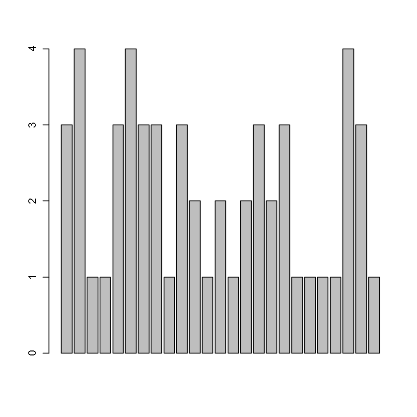

```r
## 2.1.2 Barplots
beer <- c(3,4,1,1,3,4,3,3,1,3,2,1,2,1,2,3,2,3,1,1,1,1,4,3,1)

# a bar plot with no information(wrong)
barplot(beer)
```

```
beer
 1  2  3  4
10  4  8  3
```

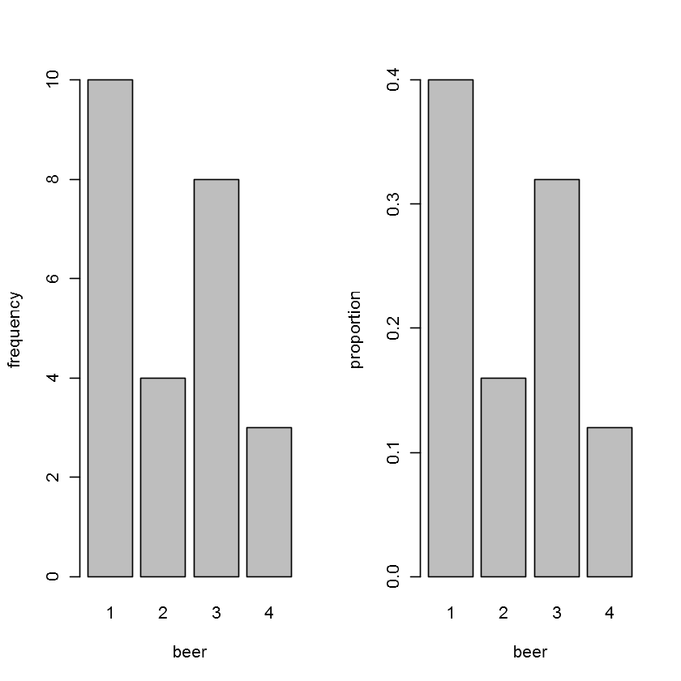

```r
par(mfrow=c(1,2))

table(beer)

# frequency
barplot(table(beer), xlab="beer", ylab="frequency")

# proportion
barplot(table(beer)/length(beer), xlab="beer", ylab="proportion")
```

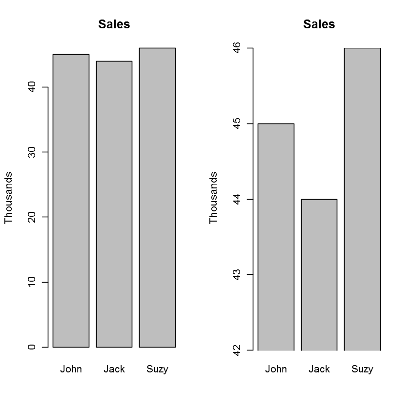

```r
## example 2.3 Misleading barplots
par(mfrow=c(1,2))

sales <- c(45, 44, 46)
names(sales) <- c("John", "Jack", "Suzy")
barplot(sales, main="Sales", ylab="Thousands")
barplot(sales, main="Sales", ylab="Thousands", ylim = c(42,46), xpd=FALSE)
```

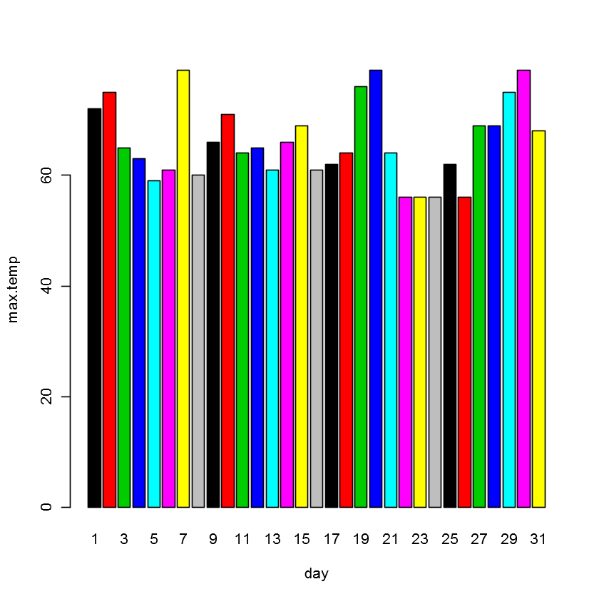

```r
barplot(central.park$MAX, names.arg = 1:31, xlab="day", ylab="max.temp", col=1:31)
```

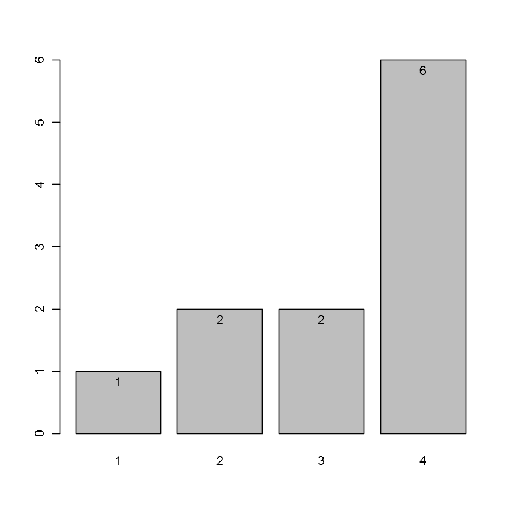

```r
our.data <- c(1,2,2,6); names(our.data) <- 1:4
bp <- barplot(our.data)
text(bp, our.data, labels=our.data, pos=1)
```

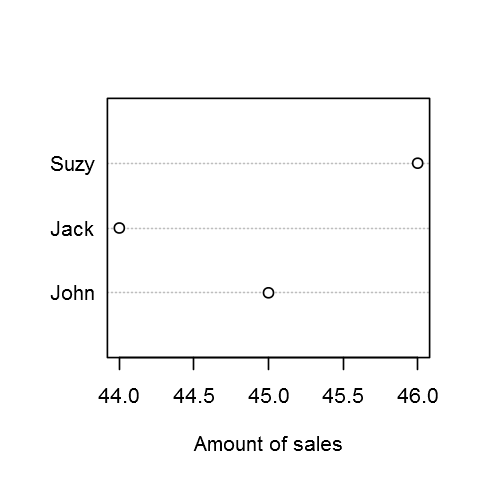

```r
## 2.1.4 Dot charts

options(repr.plot.width=4, repr.plot.height=4)

sales <- c(45, 44, 46)
names(sales) <- c("John", "Jack", "Suzy")
dotchart(sales, xlab="Amount of sales")
```

```r
## 2.1.5 Factors. A data vector type used to store categorical data

1:5
str(1:5)
```

1. 1

2. 2

3. 3

4. 4

5. 5

```
 int [1:5] 1 2 3 4 5
```

```r
factor(1:5)
str(factor(1:5))
```

1. 1

2. 2

3. 3

4. 4

5. 5

```
 Factor w/ 5 levels "1","2","3","4",..: 1 2 3 4 5
```

```r
## sort() 함수로 factor의 순서를 바꿀 수 있음

sort(factor(1:5), decreasing = TRUE)
```

1. 5

2. 4

3. 3

4. 2

5. 1

```r
## factors are not numeric
mean(factor(1:5))
```

```
[1] NA
```

```r
## letters: a 부터 z 까지 영어 소문자를 저장한 character vector.
letters[1:5]
str(letters[1:5])
```

1. 'a'

2. 'b'

3. 'c'

4. 'd'

5. 'e'

```
 chr [1:5] "a" "b" "c" "d" "e"
```

```r
## character vector 역시 factor 함수를 사용하여 자료 형태를 바꿀 수 있다.
factor(letters[1:5])
str(factor(letters[1:5]))
```

1. a

2. b

3. c

4. d

5. e

```
 Factor w/ 5 levels "a","b","c","d",..: 1 2 3 4 5
```

```r
## LETTERS: A 부터 Z 까지 영어 대문자를 저장한 character vector.
LETTERS[1:5]
```

1. 'A'

2. 'B'

3. 'C'

4. 'D'

5. 'E'

```r
## 역시나 역순으로 배열하는 것도 가능하다.
sort(LETTERS[1:5], decreasing=TRUE)
```

1. 'E'

2. 'D'

3. 'C'

4. 'B'

5. 'A'

```r
## 2.1.6 Problems

## 2.4
attach(central.park)
WX
```

1. 18

2. 1

3. NA

4. NA

5. 1

6. 18

7. 18

8. 1

9. 18

10. 18

11. 1

12. 18

13. NA

14. NA

15. NA

16. NA

17. NA

18. 1

19. NA

20. NA

21. 1

22. 1

23. 1

24. 1

25. 18

26. 1

27. NA

28. 18

29. 18

30. 18

31. 18

```r
table(WX)
```

```
WX
 1 18
10 11
```

```r
table(WX, exclude=FALSE)
detach(central.park)
```

```
WX
   1   18 <NA>
  10   11   10
```

```r
## 2.8

attach(npdb)
table(state)
```

```
state
  AK   AL   AR   AS   AZ   CA   CO   CT   DC   DE   FL   GA   GU   HI   IA   ID
  13   39   56    1  153 1566  123   41   11   11  744  148    1   23   87   23
  IL   IN   KS   KY   LA   MA   MD   ME   MI   MN   MO   MS   MT   NC   ND   NE
 135   48   75  171   99   68   90   17  179   76  120   79   37  106   30   46
  NH   NJ   NM   NV   NY   OH   OK   OR   PA   PR   RI   SC   SD   TN   TX   UT
  17  108   50   47  353  252  100   80  196   44   18   65   17  120  442   64
  VA   VT   WA   WI   WV   WY
 110   14  160   43   55   26
```

```r
sort(table(state), decreasing=TRUE)
```

```
state
  CA   FL   TX   NY   OH   PA   MI   KY   WA   AZ   GA   IL   CO   MO   TN   VA
1566  744  442  353  252  196  179  171  160  153  148  135  123  120  120  110
  NJ   NC   OK   LA   MD   IA   OR   MS   MN   KS   MA   SC   UT   AR   WV   NM
 108  106  100   99   90   87   80   79   76   75   68   65   64   56   55   50
  IN   NV   NE   PR   WI   CT   AL   MT   ND   WY   HI   ID   RI   ME   NH   SD
  48   47   46   44   43   41   39   37   30   26   23   23   18   17   17   17
  VT   AK   DC   DE   AS   GU
  14   13   11   11    1    1
```

```r
summary(npdb)
```

```
     state          field            age            year
 CA     :1566   Min.   : 10.0   Min.   :20.0   Min.   :2000
 FL     : 744   1st Qu.: 10.0   1st Qu.:40.0   1st Qu.:2000
 TX     : 442   Median : 10.0   Median :40.0   Median :2000
 NY     : 353   Mean   : 60.1   Mean   :43.9   Mean   :2000
 OH     : 252   3rd Qu.: 30.0   3rd Qu.:50.0   3rd Qu.:2001
 PA     : 196   Max.   :999.0   Max.   :80.0   Max.   :2003
 (Other):3244
     amount               ID
 Min.   :      50   Min.   :    43
 1st Qu.:    8750   1st Qu.:133861
 Median :   37500   Median :179788
 Mean   :  166257   Mean   :152454
 3rd Qu.:  175000   3rd Qu.:189202
 Max.   :25000000   Max.   :195841
```

```r
table(ID)
```

```
ID
    43     67     97    390    447    485    487    585    607    845    944
     1      1      1      1      1      1      1      1      1      1      1
   948   1096   1162   1279   1303   1324   1347   1358   1374   1384   1391
     1      1      1      1      1      1      1      1      1      1      1
  1397   1421   1422   1442   1456   1606   1607   1629   1657   1765   1815
     1      1      2      1      1      1      1      1      1      1      1
  1937   1955   1960   1997   2009   2041   2044   2118   2192   2211   2220
     1      1      1      1      1      1      1      2      1      1      1
  2249   2273   2276   2292   2326   2376   2412   2419   2425   2444   2482
     3      1      1      1      1      1      1      1      1      2      1
  2487   2546   2556   2591   2595   2638   2650   2708   2752   2787   2947
     1      1      1      1      1      1      1      1      1      2      1
  3019   3043   3079   3106   3182   3339   3346   3401   3454   3455   3468
     1      1      1      1      1      1      1      1      1      1      1
```

[output cut: 1144 more lines]

```r
table(npdb$ID)
```

```
    43     67     97    390    447    485    487    585    607    845    944
     1      1      1      1      1      1      1      1      1      1      1
   948   1096   1162   1279   1303   1324   1347   1358   1374   1384   1391
     1      1      1      1      1      1      1      1      1      1      1
  1397   1421   1422   1442   1456   1606   1607   1629   1657   1765   1815
     1      1      2      1      1      1      1      1      1      1      1
  1937   1955   1960   1997   2009   2041   2044   2118   2192   2211   2220
     1      1      1      1      1      1      1      2      1      1      1
  2249   2273   2276   2292   2326   2376   2412   2419   2425   2444   2482
     3      1      1      1      1      1      1      1      1      2      1
  2487   2546   2556   2591   2595   2638   2650   2708   2752   2787   2947
     1      1      1      1      1      1      1      1      1      2      1
  3019   3043   3079   3106   3182   3339   3346   3401   3454   3455   3468
     1      1      1      1      1      1      1      1      1      1      1
  3554   3661   3681   3727   3779   3801   3812   3818   3859   3937   3984
```

[output cut: 1143 more lines]

```r
table(table(ID))
```

```
   1    2    3    4    5    6    8   11   15   22   73
6105  235   12    4    7    1    1    1    1    1    1
```

```r
detach(npdb)
```

# 2.2 Numeric data

```r
# 2.2.1 stem and leaf
x <- c(2,3,16,23,14,12,4,13,2,0,0,0,6,28,31,14,4,8,2,5)
stem(x)
```

```
  The decimal point is 1 digit(s) to the right of the |

  0 | 000222344568
  1 | 23446
  2 | 38
  3 | 1
```

```r
stem(x, scale=2)
```

```
  The decimal point is 1 digit(s) to the right of the |

  0 | 000222344
  0 | 568
  1 | 2344
  1 | 6
  2 | 3
  2 | 8
  3 | 1
```

```r
# 2.2.2 Strip charts
attach(kid.weights)
```

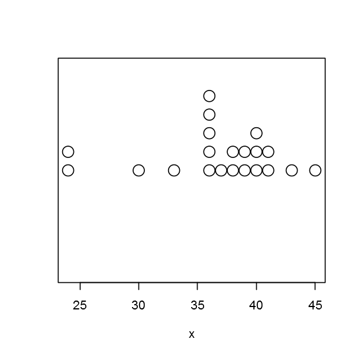

```r
x <- height[48 <= age & age < 60]
options(repr.plot.width = 5, repr.plot.height = 5)
## pch = plot character, cex = size of the plot character
## offset = pushes the point apart
stripchart(x, method="stack", xlab="x", pch=1, offset=1,cex=2)
detach(kid.weights)
```

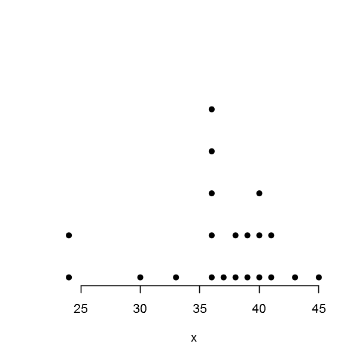

```r
DOTplot(x)
```

```r
# 2.2.3 The center: mean, median, and mode

x <- c(2,3,16,23,14,12,4,13,2,0,0,0,6,28,31,14,4,8,2,5)
sum(x)/length(x)
```

9.35

```r
bar <- c(50, 60, 100, 75, 200)
bar.with.gates <- c(bar, 50000)
mean(bar)
mean(bar.with.gates)
median(bar)
median(bar.with.gates)
```

97

8414.16666666667

75

87.5

```r
## trimmed mean
income <- cfb$INCOME
mean(income)
```

63402.661802347

```r
median(income)
## trim the highest and the lowest 20%, then get the mean
mean(income, trim=.2)
## the percentage of the values less than the sample mean
sum(income <= mean(income))/length(income)*100
```

38032.695375

41991.86469959

70.5

```r
x <- c(72, 75, 84, 84, 98, 94, 55, 62)
## what does the code below mean??
which(table(x) == max(table(x)))
```

**84:** 5

```r
table(x)
```

```
x
55 62 72 75 84 94 98
 1  1  1  1  2  1  1
```

```r
max(table(x))
```

2

```r
table(x) == 2
```

**55**

FALSE

**62**

FALSE

**72**

FALSE

**75**

FALSE

**84**

TRUE

**94**

FALSE

**98**

FALSE

```r
## which는 index 를 뱉어낸다.
which(table(x) == 2)
```

**84:** 5

### Example 2.6 Another formula for the mean(Expected Value)

$${\bar{x}} = \frac{1}{n} \sum{x_i} = \frac{1}{n} \sum_{k\ in\ Range(x)}^{}k*n_k = \sum_{k\ in\ Range(x)}{k*p_k}$$

```r
x1 <- c(3,5,4,4,4,2,2)

bar.x <- sum(x1)/length(x1)
bar.x2 <- (3*1+5*1+4*3+2*2)/length(x1)
bar.x3 <- (3*(1/length(x1)) + 5*(1/length(x1)) + 4*(3/length(x1)) + 2*(2/length(x1)))
```

```r
bar.x
bar.x2
bar.x3
```

3.42857142857143

3.42857142857143

3.42857142857143

### 2.2.4 variation: the variance, standard deviation, and IQR

### The sample range

- the distance between the smallest and largest values
- a pair of the two values

### distance = $|x-y|$, non-negative

### difference(deviation) = $x-y$, may be negative

### sample variance: deviations from the center

center is set to be the mean of a sample A sum of all these deviations == 0 So, we add the squared deviations $$ s^2(=sample\ variance) = \frac{1}{n-1} \sum_{i\ =\ 1}^{n}(x_i - \bar{x})^2$$

why divide by (n-1) instead of n? http://nebula.deanza.edu/~bloom/math10/m10divideby_nminus1.pdf

### sample standard deviation: the square root of the variance

$$s = \sqrt{\frac{1}{n-1} \sum_{i\ =\ 1}^{n}(x_i - \bar{x})^2}$$

```r
test.scores <- c(80, 85, 77, 87, 82, 88)
test.scores.b <- c(100, 90, 50, 57, 82, 100, 86)
mean(test.scores)
mean(test.scores.b)
```

83.1666666666667

80.7142857142857

```r
n = length(test.scores)
(1/(n-1))*sum((test.scores - mean(test.scores))^2)
var(test.scores)
sd(test.scores)
```

18.1666666666667

18.1666666666667

4.26223728418147

### Quantiles, quintiles, percentiles, and more

The standarde deviation, like the mean, can be skewed when an exceptionally large or small value is in the data.

Inter-quantile range(IQR) is a more resistant alternative. Take the range of the middle 50% of the data.

pth quantile = 1+p(n-1) in the sorted data

percentiles = scale of 100 quartiles = 0, 25, 50, 75, 100 percentiles quintiles = 0, 20, 40, 60, 80, 100 percentiles

```r
x = 0:5
x
median(x)
quantile(x, 0.25)
quantile(x, c(0.25, 0.5, 0.75))
quantile(x)
```

1. 0

2. 1

3. 2

4. 3

5. 4

6. 5

2.5

**25%:** 1.25

**25%**

1.25

**50%**

2.5

**75%**

3.75

**0%**

0

**25%**

1.25

**50%**

2.5

**75%**

3.75

**100%**

5

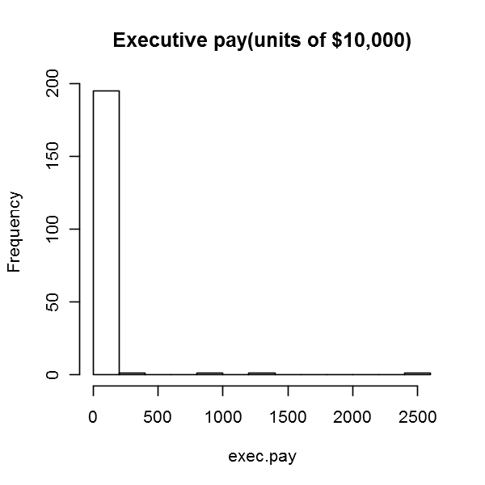

```r
hist(exec.pay, main = "Executive pay(units of $10,000)")
```

```r
## what's the top 1% exec.pay?
quantile(exec.pay, 0.99)

## what about the top 0.1%?
quantile(exec.pay, 0.999)

## what percentage of CEOs make 100,000 or less?
(sum(exec.pay <= 10)/length(exec.pay))*100
```

**99%:** 906.620000000003

**99.9%:** 2256.75799999999

14.572864321608

```r
## the distance between the 75th percentile and the 25th percentile
quantile(exec.pay)
## this is a more "realistic" range of exec.pay data
IQR(exec.pay)
## skewed data makes the standard deviation less favorable in describing the data
sd(exec.pay)
```

**0%**

0

**25%**

14

**50%**

27

**75%**

41.5

**100%**

2510

27.5

207.043541605142

### z-scores: the number of standard deviations the value is from the sample mean of the data set.

$$ z = \frac{x_i - \bar{x}}{s}$$

scale() = returns the collection of z scores for a data set

```r
scale(exec.pay)
```

| 0.367607 |
| --- |
| 0.068153 |
| -0.250621 |
| -0.105724 |
| -0.067085 |
| -0.081574 |
| -0.245791 |
| -0.245791 |
| -0.231301 |
| -0.236131 |
| -0.192662 |
| -0.245791 |
| 0.169581 |
| -0.125043 |
| -0.255451 |
| -0.221642 |
| -0.100894 |
| -0.231301 |
| -0.149193 |
| -0.187832 |
| 0.000534 |
| -0.120214 |
| -0.207152 |
| -0.115384 |
| -0.149193 |
| 0.493184 |
| 0.135771 |
| -0.139533 |
| -0.260281 |
| 0.362777 |
| ... |
| -0.216812 |
| -0.178172 |
| -0.052595 |
| 0.000534 |
| -0.154023 |
| 0.068153 |
| -0.086404 |
| -0.173343 |
| -0.207152 |
| -0.245791 |
| 0.005364 |
| -0.192662 |
| -0.178172 |
| -0.163683 |
| -0.139533 |
| 0.517333 |
| -0.197492 |
| -0.221642 |
| -0.226471 |
| 0.415906 |
| 1.077602 |
| -0.231301 |
| -0.033275 |
| -0.163683 |
| -0.211982 |
| -0.149193 |
| -0.042935 |
| -0.216812 |
| -0.183002 |
| -0.158853 |

```r
### Numeric summaries of the data
### Use summary() function
options(digits =8)
summary(exec.pay)
```

```
    Min.  1st Qu.   Median     Mean  3rd Qu.     Max.
   0.000   14.000   27.000   59.889   41.500 2510.000
```

```r
### The mean of exec.pay data set is actually the 84th percepntile
sum(exec.pay <= mean(exec.pay))/length(exec.pay)
```

0.839195979899497

```r
dev.off()
```

**null device:** 1

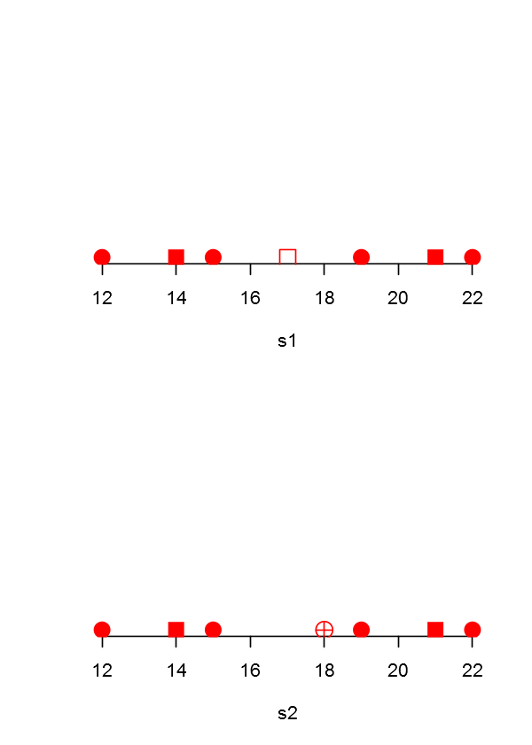

```r
### Hinges and the five-number summary

## lower hinge = the median of the lower half of the data
## upper hinge = the median of the upper half of the data
s1 <- c(12, 14, 15, 17, 19, 21, 22)
s2 <- c(12, 14, 15, 18, 19, 21, 22)
par(mfrow=c(2,1))
options(repr.plot.height = 7)
DOTplot(s1, cex = 2, pch=c(16, 15, 16, 0, 16, 15, 16), col = 2)
DOTplot(s2, cex = 2, pch=c(16, 15, 16, 10, 16, 15, 16), col = 2)
```

### 2.2.5 Problems

```r
# 2.17

# 1)
attach(nym.2002)
sum(time<180)/length(time)

# 2)
quantile(time, 0.9)
quantile(time, 0.75)

# 3)
quantile(time, 0.1)
detach(nym.2002)
```

0.026

**90%:** 331.75

**75%:** 294.854166666666

**10%:** 208.695

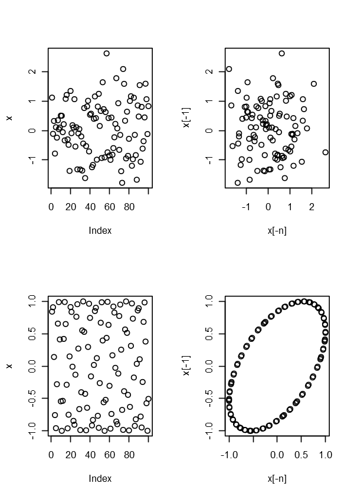

```r
# 2.26
par(mfrow=c(2,2))
x = rnorm(100)
n = length(x)
plot(x)
plot(x[-n], x[-1])

x = sin(1:100)
n = length(x)
plot(x)
plot(x[-n], x[-1])
```

```r
# 2.27

x <- c(4,6,1,2,5,7)
a <- 1.8
y <- c(11, 15, 18, 17, 14, 16)

sum(a*x)
a*sum(x)
sum(x+y)
sum(x)+sum(y)
```

45

45

116

116

## 2.3 Shape of a distribution

### 2.3.1 Histogram

similar to barplot, but different. The histogram uses bars to indicate frequency or proportion, but for an INTERVAL not a CATEGORY!!

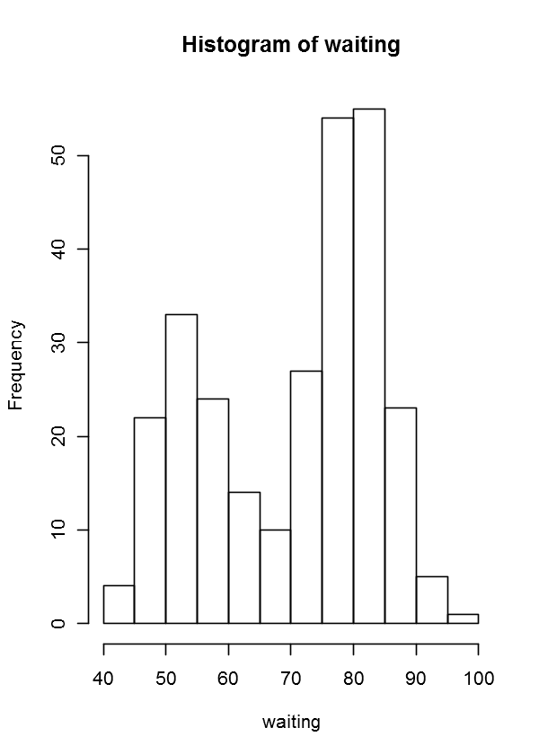

```r
attach(faithful)
hist(waiting)
detach(faithful)
```

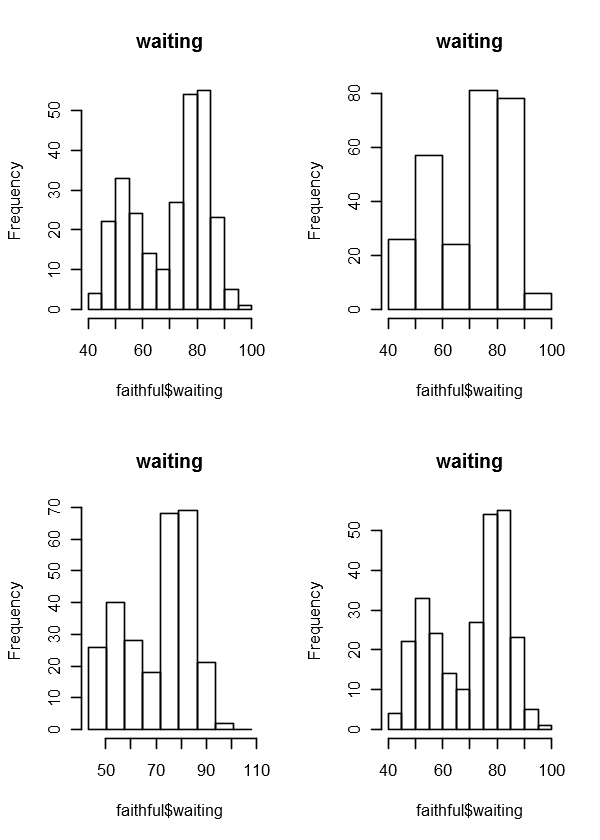

```r
## setting the bin size

par(mfrow=c(2,2))
hist(faithful$waiting, main="waiting")
hist(faithful$waiting, breaks=5, main="waiting")
hist(faithful$waiting, breaks=seq(43, 108, length=10), main="waiting")
hist(faithful$waiting, breaks="Scott", main="waiting")
```

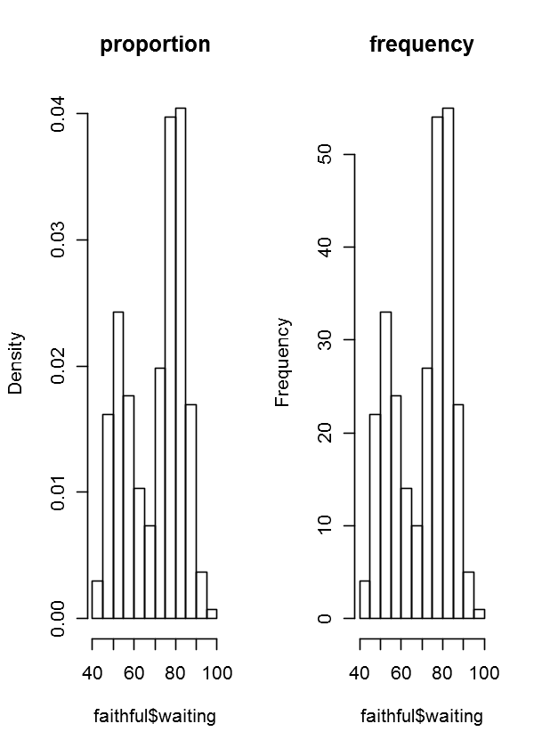

```r
## drawing a histogram of proportions

par(mfrow=c(1,2))
hist(faithful$waiting, prob=T, main="proportion")
hist(faithful$waiting, main="frequency")
```

R uses intervals of the type (a,b]. Thus, a(=minimum) is excluded and b(=maximum) is included. If we want the left-most interval to be of the type [a,b], use the argument "include.lowerst = TRUE"

```r
## Density estimates and frequency polygons

bins <- seq(42, 109, by=10)
bins
### see what the function 'cut' does to a vector
freqs <- table(cut(faithful$waiting, bins))
```

1. 42

2. 52

3. 62

4. 72

5. 82

6. 92

7. 102

```r
freqs
```

```
 (42,52]  (52,62]  (62,72]  (72,82]  (82,92] (92,102]
      37       50       26      100       55        4
```

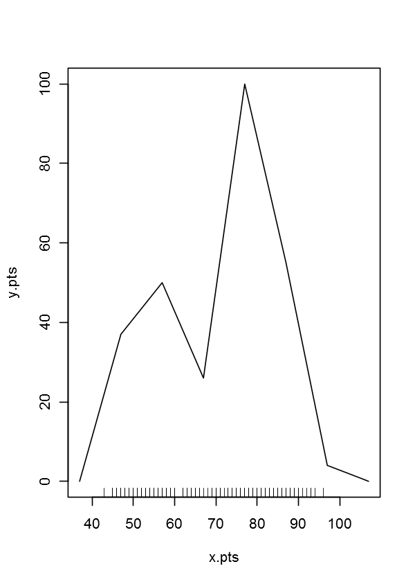

```r
y.pts <- c(0, freqs, 0)
x.pts <- seq(37, 107, by=10)
plot(x.pts, y.pts, type='l')
### actual values represented
rug(faithful$waiting)
```

```r
y.pts
```

**1**

0

**(42,52]**

37

**(52,62]**

50

**(62,72]**

26

**(72,82]**

100

**(82,92]**

55

**(92,102]**

4

**8**

0

```
Error in detach(waiting): invalid 'name' argument
Traceback:

1. detach(waiting)
2. stop("invalid 'name' argument")
```

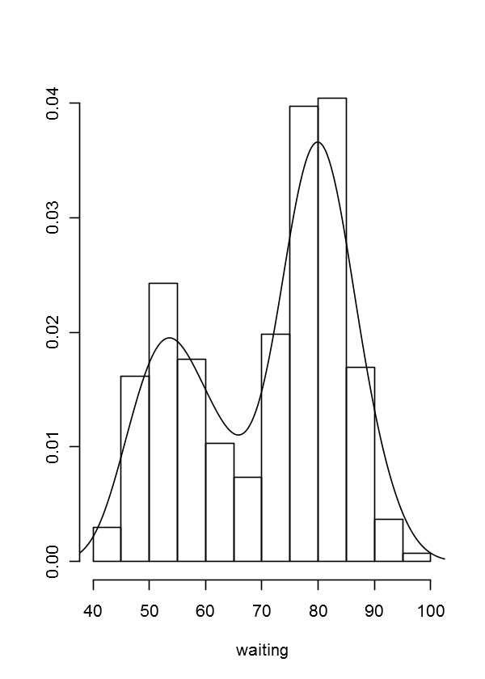

```r
## estimating the density

attach(faithful)
hist(waiting, breaks="scott", prob=T, main="", ylab="")
lines(density(waiting))
detach(waiting)
```

### 2.3.2 Modes, symmetry, and skew

```r
## Modes

# A mode of a distribution is a peak, or a local maximum, in its density.
# one mode = unimodal; two modes = bimodal; more than two = multimodal

# waiting =??
```

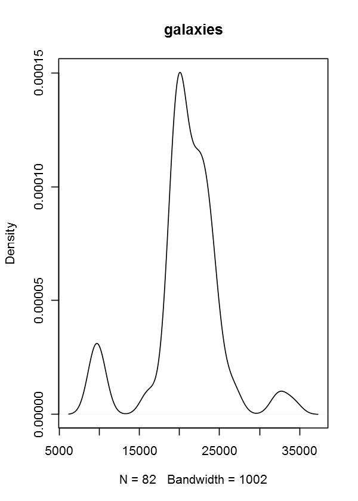

```r
library(MASS)
plot(density(galaxies), main="galaxies")
```

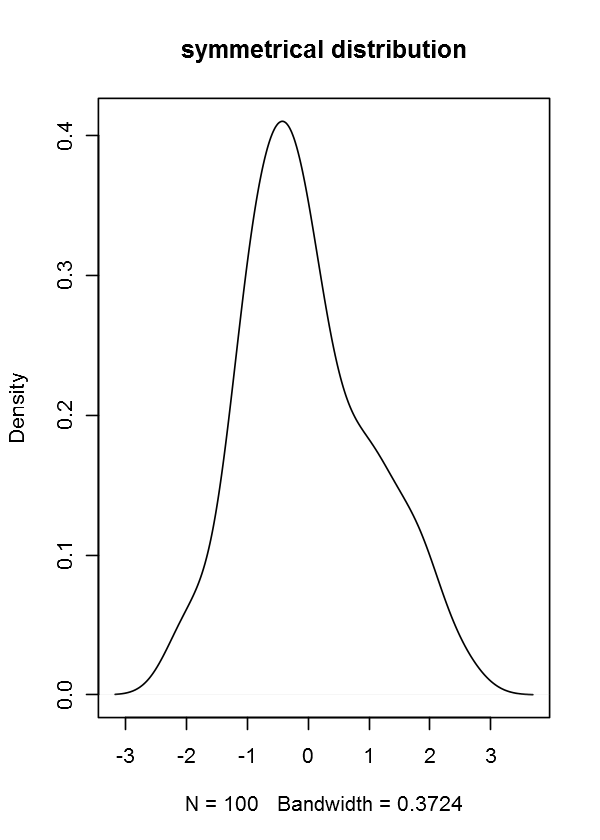

```r
## Symmetry
# spreads out in a similar way to the left and right of some central point.

x <- rnorm(100)
plot(density(x), main="symmetrical distribution")
```

### Tails of a distribution and skew

- long-tailed distribution: data set contains values far from the body of the data
- short-tailed distribution: no values far from the body
- skewed distribution: one tail is significantly fatter or longer than the other
- skewed left, skewed right
- outlier: a data point that doesn't fit the pattern set by the majority of the data

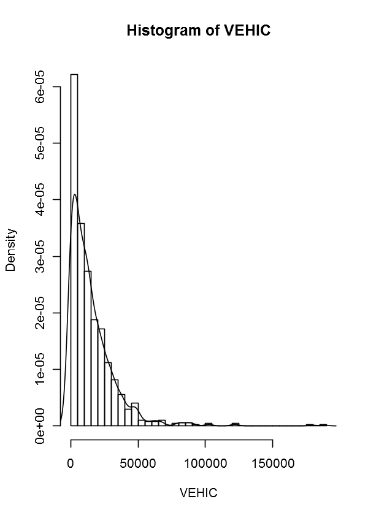

```r
attach(cfb)
hist(VEHIC, breaks="Scott", prob=T)
lines(density(VEHIC))
detach(cfb)
```

- When a data set is symmetric and not too long tailed: mean ~= median ~= trimmed mean
- When a data set has a long tail: mean is a poor indicator of the center. trimmed mean or median is preferred if symmetric median is preferred if skewed

IQR is preferred to the standard deviation when summarizing spread in a long-tailed distribution

### 2.3.3 Boxplots

- histograms are not good for comparing distributions -> use boxplots instead!
- A boxplot graphically displays the five-number summary
- min, the lower hinge, median, the upper hinge, max

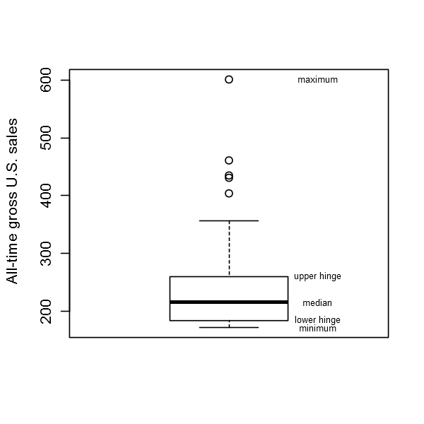

```r
attach(alltime.movies)
options(repr.plot.height = 5, repr.plot.width = 5)
boxplot(Gross, ylab="All-time gross U.S. sales")
f <- fivenum(Gross)
text(rep(1.3, 5), f,
     labels=c("minimum", "lower hinge", "median", "upper hinge", "maximum"),
    cex=0.6)
```

```r
the.names <- rownames(alltime.movies)
the.names[Gross > f[4] + 1.5*(f[4]-f[2])]
detach(alltime.movies)
```

1. 'Titanic '

2. 'Star Wars '

3. 'E.T. '

4. 'Star Wars: The Phantom Menace '

5. 'Spider-Man '

### 2.3.4 Problems

```
   Min. 1st Qu.  Median    Mean 3rd Qu.    Max.
  2.790   3.075   3.220   3.328   3.360   4.640
```

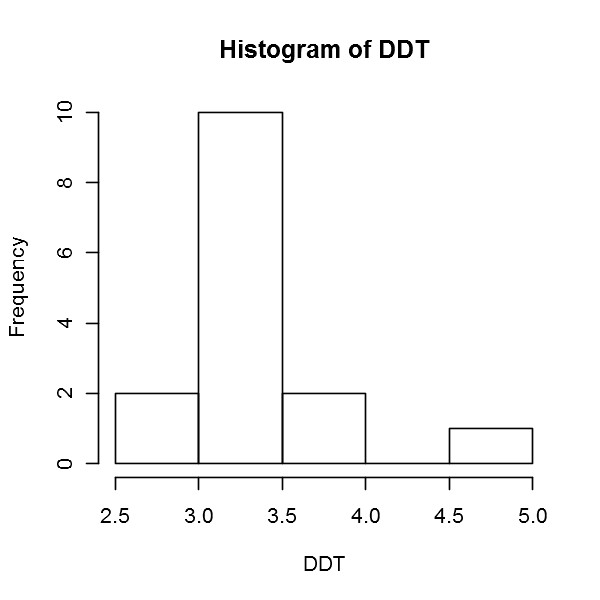

```r
# 2.34

summary(DDT)
hist(DDT)
```

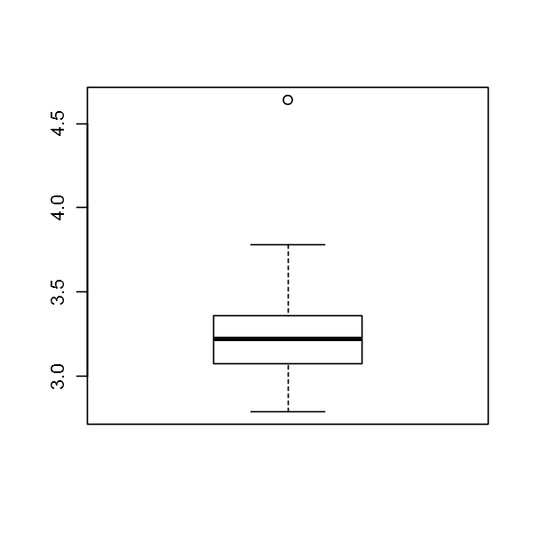

```r
boxplot(DDT)
```

```r
mean(DDT)
sd(DDT)
```

3.328

0.437153127797179

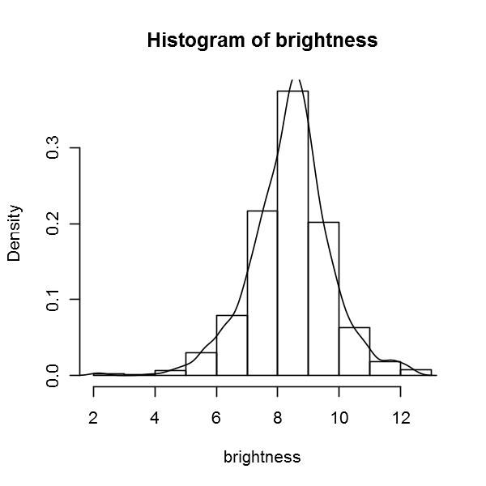

```r
# 2.43

hist(brightness, prob = T)
lines(density(brightness))
```

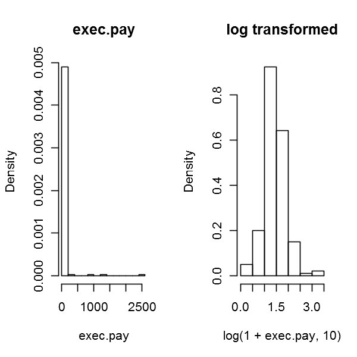

```r
# 2.45

par(mfrow=c(1,2))
hist(exec.pay, prob=T, main = "exec.pay")
hist(log(1+exec.pay, 10), prob = T, main = "log transformed")
```